# Capstone_ModifiedTOC_2

- 1. Introduction: Problem Statement
- 2. Loading Packages
- 3. Data Description
- 4. Target Variable distribution
- 5. Missing and Unique Values
  - 5.1 Unique Values in Categorical Columns
  - 5.2 Filling Car Age Missing Values
    - 5.2.1 Relation between Car Age and Target
  - 5.3 Filling Occupation Type Missing Values
    - 5.3.1 Relationship Between Occupation Type and Target
  - 5.4 Organisation Type Missing Values
  - 5.5 Relationship Between Gender and Target
- 6. Finding Correlation
- 7. Outliers
  - 7.1 Fixing Days Employed Values
  - 7.2 Fixing Children Count
  - 7.3 Fixing Days Birth, Days ID Publish, Days Registration
- 8. Contributions

# 1. Introduction: Problem Statement

### A significant portion of the population, particularly those with insufficient or non-existent credit histories, struggle to obtain loans at Home Credit. This population is often vulnerable to untrustworthy lenders who may take advantage of them. Home Credit looks to address this problem by providing a positive and safe borrowing experience for the unbanked population. The goal for this project will be the reduction in loan rejections for creditworthy individuals, and the improvement in clients' loan repayment rates compared to previous methods by using the target variable of whether a client is likely to repay the loan or not.

# 2. Loading Packages

```python
import numpy as np
import pandas as pd
import matplotlib.pyplot as plt
import seaborn as sns
```

back to top

# 3. Data Description

```python
app_train_data= pd.read_csv("application_train.csv")
```

```python
app_train_data.head()
```

|  | SK_ID_CURR | TARGET | NAME_CONTRACT_TYPE | CODE_GENDER | FLAG_OWN_CAR | FLAG_OWN_REALTY | CNT_CHILDREN | AMT_INCOME_TOTAL | AMT_CREDIT | AMT_ANNUITY | ... | FLAG_DOCUMENT_18 | FLAG_DOCUMENT_19 | FLAG_DOCUMENT_20 | FLAG_DOCUMENT_21 | AMT_REQ_CREDIT_BUREAU_HOUR | AMT_REQ_CREDIT_BUREAU_DAY | AMT_REQ_CREDIT_BUREAU_WEEK | AMT_REQ_CREDIT_BUREAU_MON | AMT_REQ_CREDIT_BUREAU_QRT | AMT_REQ_CREDIT_BUREAU_YEAR |
| --- | --- | --- | --- | --- | --- | --- | --- | --- | --- | --- | --- | --- | --- | --- | --- | --- | --- | --- | --- | --- | --- |
| 0 | 100002 | 1 | Cash loans | M | N | Y | 0 | 202500.0 | 406597.5 | 24700.5 | ... | 0 | 0 | 0 | 0 | 0.0 | 0.0 | 0.0 | 0.0 | 0.0 | 1.0 |
| 1 | 100003 | 0 | Cash loans | F | N | N | 0 | 270000.0 | 1293502.5 | 35698.5 | ... | 0 | 0 | 0 | 0 | 0.0 | 0.0 | 0.0 | 0.0 | 0.0 | 0.0 |
| 2 | 100004 | 0 | Revolving loans | M | Y | Y | 0 | 67500.0 | 135000.0 | 6750.0 | ... | 0 | 0 | 0 | 0 | 0.0 | 0.0 | 0.0 | 0.0 | 0.0 | 0.0 |
| 3 | 100006 | 0 | Cash loans | F | N | Y | 0 | 135000.0 | 312682.5 | 29686.5 | ... | 0 | 0 | 0 | 0 | NaN | NaN | NaN | NaN | NaN | NaN |
| 4 | 100007 | 0 | Cash loans | M | N | Y | 0 | 121500.0 | 513000.0 | 21865.5 | ... | 0 | 0 | 0 | 0 | 0.0 | 0.0 | 0.0 | 0.0 | 0.0 | 0.0 |

5 rows × 122 columns

```python
print('Shape of training features:', app_train_data.shape)
```

```
Shape of training features: (307511, 122)
```

```python
app_train_data.select_dtypes(include='number').drop(['TARGET', 'SK_ID_CURR'], axis=1).describe()
```

|  | CNT_CHILDREN | AMT_INCOME_TOTAL | AMT_CREDIT | AMT_ANNUITY | AMT_GOODS_PRICE | REGION_POPULATION_RELATIVE | DAYS_BIRTH | DAYS_EMPLOYED | DAYS_REGISTRATION | DAYS_ID_PUBLISH | ... | FLAG_DOCUMENT_18 | FLAG_DOCUMENT_19 | FLAG_DOCUMENT_20 | FLAG_DOCUMENT_21 | AMT_REQ_CREDIT_BUREAU_HOUR | AMT_REQ_CREDIT_BUREAU_DAY | AMT_REQ_CREDIT_BUREAU_WEEK | AMT_REQ_CREDIT_BUREAU_MON | AMT_REQ_CREDIT_BUREAU_QRT | AMT_REQ_CREDIT_BUREAU_YEAR |
| --- | --- | --- | --- | --- | --- | --- | --- | --- | --- | --- | --- | --- | --- | --- | --- | --- | --- | --- | --- | --- | --- |
| count | 307511.000000 | 3.075110e+05 | 3.075110e+05 | 307499.000000 | 3.072330e+05 | 307511.000000 | 307511.000000 | 307511.000000 | 307511.000000 | 307511.000000 | ... | 307511.000000 | 307511.000000 | 307511.000000 | 307511.000000 | 265992.000000 | 265992.000000 | 265992.000000 | 265992.000000 | 265992.000000 | 265992.000000 |
| mean | 0.417052 | 1.687979e+05 | 5.990260e+05 | 27108.573909 | 5.383962e+05 | 0.020868 | -16036.995067 | 63815.045904 | -4986.120328 | -2994.202373 | ... | 0.008130 | 0.000595 | 0.000507 | 0.000335 | 0.006402 | 0.007000 | 0.034362 | 0.267395 | 0.265474 | 1.899974 |
| std | 0.722121 | 2.371231e+05 | 4.024908e+05 | 14493.737315 | 3.694465e+05 | 0.013831 | 4363.988632 | 141275.766519 | 3522.886321 | 1509.450419 | ... | 0.089798 | 0.024387 | 0.022518 | 0.018299 | 0.083849 | 0.110757 | 0.204685 | 0.916002 | 0.794056 | 1.869295 |
| min | 0.000000 | 2.565000e+04 | 4.500000e+04 | 1615.500000 | 4.050000e+04 | 0.000290 | -25229.000000 | -17912.000000 | -24672.000000 | -7197.000000 | ... | 0.000000 | 0.000000 | 0.000000 | 0.000000 | 0.000000 | 0.000000 | 0.000000 | 0.000000 | 0.000000 | 0.000000 |
| 25% | 0.000000 | 1.125000e+05 | 2.700000e+05 | 16524.000000 | 2.385000e+05 | 0.010006 | -19682.000000 | -2760.000000 | -7479.500000 | -4299.000000 | ... | 0.000000 | 0.000000 | 0.000000 | 0.000000 | 0.000000 | 0.000000 | 0.000000 | 0.000000 | 0.000000 | 0.000000 |
| 50% | 0.000000 | 1.471500e+05 | 5.135310e+05 | 24903.000000 | 4.500000e+05 | 0.018850 | -15750.000000 | -1213.000000 | -4504.000000 | -3254.000000 | ... | 0.000000 | 0.000000 | 0.000000 | 0.000000 | 0.000000 | 0.000000 | 0.000000 | 0.000000 | 0.000000 | 1.000000 |
| 75% | 1.000000 | 2.025000e+05 | 8.086500e+05 | 34596.000000 | 6.795000e+05 | 0.028663 | -12413.000000 | -289.000000 | -2010.000000 | -1720.000000 | ... | 0.000000 | 0.000000 | 0.000000 | 0.000000 | 0.000000 | 0.000000 | 0.000000 | 0.000000 | 0.000000 | 3.000000 |
| max | 19.000000 | 1.170000e+08 | 4.050000e+06 | 258025.500000 | 4.050000e+06 | 0.072508 | -7489.000000 | 365243.000000 | 0.000000 | 0.000000 | ... | 1.000000 | 1.000000 | 1.000000 | 1.000000 | 4.000000 | 9.000000 | 8.000000 | 27.000000 | 261.000000 | 25.000000 |

8 rows × 104 columns

```python
# How much variability exists within each variable?
```

back to top

# 4. Target Variable distribution

```python
#Majority class classifier count
target_counts=app_train_data['TARGET'].value_counts()
target_percent=target_counts/target_counts.sum()*100

pd.concat([target_counts,target_percent],axis=1,keys=['Count','Percent'])
```

|  | Count | Percent |
| --- | --- | --- |
| 0 | 282686 | 91.927118 |
| 1 | 24825 | 8.072882 |

```python
#accuracy be for a simple model consisting in a majority class classifier
class_counts = app_train_data['TARGET'].value_counts()
# Determine the majority class
majority_class = class_counts.idxmax()
# Calculate the proportion of the majority class in the dataset
majority_proportion = class_counts[majority_class] / len(app_train_data)
# Calculate the accuracy of the majority class classifier
accuracy = majority_proportion * 100  # Multiply by 100 to get the percentage
print("Accuracy of the majority class classifier: {:.2f}%".format(accuracy))
```

```
Accuracy of the majority class classifier: 91.93%
```

back to top

# 5. Missing and Unique Values

```python
total=app_train_data.isnull().sum().sort_values(ascending=False)
percentage=(app_train_data.isnull().sum()/app_train_data.isnull().count()*100).sort_values(ascending = False)

pd.concat([total,percentage],axis=1,keys=['total','percentage'])
```

|  | total | percentage |
| --- | --- | --- |
| COMMONAREA_MEDI | 214865 | 69.872297 |
| COMMONAREA_AVG | 214865 | 69.872297 |
| COMMONAREA_MODE | 214865 | 69.872297 |
| NONLIVINGAPARTMENTS_MODE | 213514 | 69.432963 |
| NONLIVINGAPARTMENTS_AVG | 213514 | 69.432963 |
| ... | ... | ... |
| NAME_HOUSING_TYPE | 0 | 0.000000 |
| NAME_FAMILY_STATUS | 0 | 0.000000 |
| NAME_EDUCATION_TYPE | 0 | 0.000000 |
| NAME_INCOME_TYPE | 0 | 0.000000 |
| SK_ID_CURR | 0 | 0.000000 |

122 rows × 2 columns

## 5.1 Unique Values in Categorical Columns

```python
#Unique values in each object column
app_train_data.select_dtypes('object').apply(pd.Series.nunique,axis=0)
```

```
NAME_CONTRACT_TYPE             2
CODE_GENDER                    3
FLAG_OWN_CAR                   2
FLAG_OWN_REALTY                2
NAME_TYPE_SUITE                7
NAME_INCOME_TYPE               8
NAME_EDUCATION_TYPE            5
NAME_FAMILY_STATUS             6
NAME_HOUSING_TYPE              6
OCCUPATION_TYPE               18
WEEKDAY_APPR_PROCESS_START     7
ORGANIZATION_TYPE             58
FONDKAPREMONT_MODE             4
HOUSETYPE_MODE                 3
WALLSMATERIAL_MODE             7
EMERGENCYSTATE_MODE            2
dtype: int64
```

## 5.2 Filling Car Age Missing Values

```python
def process_own_car_age(df):
    df['OWN_CAR_AGE'].fillna(0, inplace=True)
    df['OWN_CAR_AGE'] = df['OWN_CAR_AGE'].apply(lambda x: 0 if x == 0 else (1 if 10 <= x <= 20 else (2 if 21 <= x <= 30 else 3)))
    return df
process_own_car_age(app_train_data)
```

|  | SK_ID_CURR | TARGET | NAME_CONTRACT_TYPE | CODE_GENDER | FLAG_OWN_CAR | FLAG_OWN_REALTY | CNT_CHILDREN | AMT_INCOME_TOTAL | AMT_CREDIT | AMT_ANNUITY | ... | FLAG_DOCUMENT_18 | FLAG_DOCUMENT_19 | FLAG_DOCUMENT_20 | FLAG_DOCUMENT_21 | AMT_REQ_CREDIT_BUREAU_HOUR | AMT_REQ_CREDIT_BUREAU_DAY | AMT_REQ_CREDIT_BUREAU_WEEK | AMT_REQ_CREDIT_BUREAU_MON | AMT_REQ_CREDIT_BUREAU_QRT | AMT_REQ_CREDIT_BUREAU_YEAR |
| --- | --- | --- | --- | --- | --- | --- | --- | --- | --- | --- | --- | --- | --- | --- | --- | --- | --- | --- | --- | --- | --- |
| 0 | 100002 | 1 | Cash loans | M | N | Y | 0 | 202500.0 | 406597.5 | 24700.5 | ... | 0 | 0 | 0 | 0 | 0.0 | 0.0 | 0.0 | 0.0 | 0.0 | 1.0 |
| 1 | 100003 | 0 | Cash loans | F | N | N | 0 | 270000.0 | 1293502.5 | 35698.5 | ... | 0 | 0 | 0 | 0 | 0.0 | 0.0 | 0.0 | 0.0 | 0.0 | 0.0 |
| 2 | 100004 | 0 | Revolving loans | M | Y | Y | 0 | 67500.0 | 135000.0 | 6750.0 | ... | 0 | 0 | 0 | 0 | 0.0 | 0.0 | 0.0 | 0.0 | 0.0 | 0.0 |
| 3 | 100006 | 0 | Cash loans | F | N | Y | 0 | 135000.0 | 312682.5 | 29686.5 | ... | 0 | 0 | 0 | 0 | NaN | NaN | NaN | NaN | NaN | NaN |
| 4 | 100007 | 0 | Cash loans | M | N | Y | 0 | 121500.0 | 513000.0 | 21865.5 | ... | 0 | 0 | 0 | 0 | 0.0 | 0.0 | 0.0 | 0.0 | 0.0 | 0.0 |
| ... | ... | ... | ... | ... | ... | ... | ... | ... | ... | ... | ... | ... | ... | ... | ... | ... | ... | ... | ... | ... | ... |
| 307506 | 456251 | 0 | Cash loans | M | N | N | 0 | 157500.0 | 254700.0 | 27558.0 | ... | 0 | 0 | 0 | 0 | NaN | NaN | NaN | NaN | NaN | NaN |
| 307507 | 456252 | 0 | Cash loans | F | N | Y | 0 | 72000.0 | 269550.0 | 12001.5 | ... | 0 | 0 | 0 | 0 | NaN | NaN | NaN | NaN | NaN | NaN |
| 307508 | 456253 | 0 | Cash loans | F | N | Y | 0 | 153000.0 | 677664.0 | 29979.0 | ... | 0 | 0 | 0 | 0 | 1.0 | 0.0 | 0.0 | 1.0 | 0.0 | 1.0 |
| 307509 | 456254 | 1 | Cash loans | F | N | Y | 0 | 171000.0 | 370107.0 | 20205.0 | ... | 0 | 0 | 0 | 0 | 0.0 | 0.0 | 0.0 | 0.0 | 0.0 | 0.0 |
| 307510 | 456255 | 0 | Cash loans | F | N | N | 0 | 157500.0 | 675000.0 | 49117.5 | ... | 0 | 0 | 0 | 0 | 0.0 | 0.0 | 0.0 | 2.0 | 0.0 | 1.0 |

307511 rows × 122 columns

```python
app_train_data['OWN_CAR_AGE'].value_counts()
#Where 0 means no car and 1,2,3 represent the binned age of the car
```

```
0    205063
3     56299
1     38027
2      8122
Name: OWN_CAR_AGE, dtype: int64
```

### 5.2.1 Relation between Car Age and Target

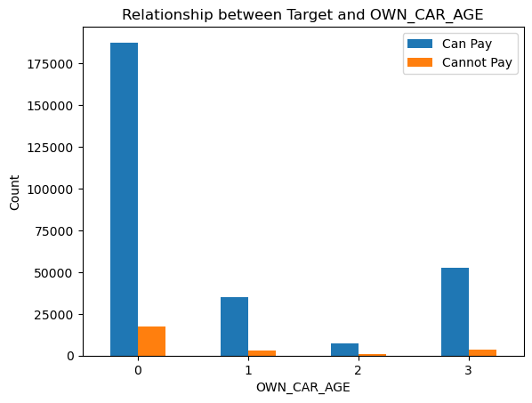

```python
plt.figure(figsize=(8, 6))
ax=app_train_data.groupby(['OWN_CAR_AGE', 'TARGET']).size().unstack().plot(kind='bar', stacked=False)
plt.xlabel('OWN_CAR_AGE')
plt.ylabel('Count')
plt.title('Relationship between Target and OWN_CAR_AGE')
plt.legend(['Can Pay', 'Cannot Pay'])
ax.set_xticklabels(ax.get_xticklabels(), rotation=0)
plt.show()
```

```python
#We can interpret that people who do not own a car/ who's car age is 0 are the one's in majority in terms of non repayment

# Are there other variables that can be more correlated with people that don't have cars with respect to the target?
```

## 5.3 Filling Occupation Type Missing Values

```python
app_train_data['OCCUPATION_TYPE'].isnull().sum()
```

```
96391
```

```python
if app_train_data['OCCUPATION_TYPE'].isnull().sum() > 0:
    column_dtype = app_train_data['OCCUPATION_TYPE'].dtype
    if column_dtype == 'object':
        print("The missing values in 'OCCUPATION_TYPE' column are categorical.")
    else:
        print("The missing values in 'OCCUPATION_TYPE' column are numerical.")
else:
    print("There are no missing values in 'OCCUPATION_TYPE' column.")
```

```
The missing values in 'OCCUPATION_TYPE' column are categorical.
```

```python
categorical_columns = ['OCCUPATION_TYPE']
for column in categorical_columns:
    if app_train_data[column].isnull().sum() > 0:
        app_train_data[column].fillna('Unknown', inplace=True)
```

```python
app_train_data['OCCUPATION_TYPE'].value_counts()
#We can see that all the missing values have been filled with an 'Unknown' occupation type
```

```
Unknown                  96391
Laborers                 55186
Sales staff              32102
Core staff               27570
Managers                 21371
Drivers                  18603
High skill tech staff    11380
Accountants               9813
Medicine staff            8537
Security staff            6721
Cooking staff             5946
Cleaning staff            4653
Private service staff     2652
Low-skill Laborers        2093
Waiters/barmen staff      1348
Secretaries               1305
Realty agents              751
HR staff                   563
IT staff                   526
Name: OCCUPATION_TYPE, dtype: int64
```

### 5.3.1 Relationship Between Occupation Type and Target

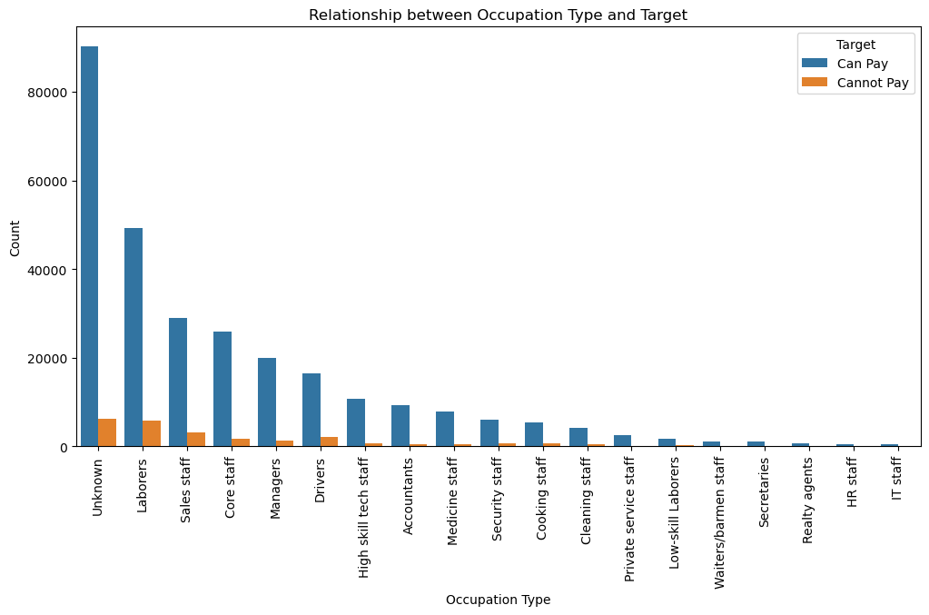

```python
sorted_occupations = app_train_data['OCCUPATION_TYPE'].value_counts().sort_values(ascending=False).index
plt.figure(figsize=(12, 6))
sns.countplot(data=app_train_data, x='OCCUPATION_TYPE', hue='TARGET',order=sorted_occupations)
plt.xticks(rotation=90)
plt.xlabel('Occupation Type')
plt.ylabel('Count')
plt.title('Relationship between Occupation Type and Target')
plt.legend(title='Target', labels=['Can Pay', 'Cannot Pay'])
plt.show()
```

## 5.4 Organisation Type Missing Values

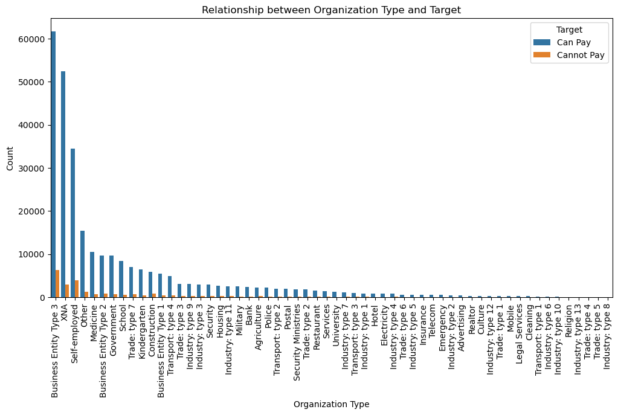

```python
sorted_organizations = app_train_data['ORGANIZATION_TYPE'].value_counts().sort_values(ascending=False).index
plt.figure(figsize=(12, 6))
sns.countplot(data=app_train_data, x='ORGANIZATION_TYPE', hue='TARGET',order=sorted_organizations)
plt.xticks(rotation=90)
plt.xlabel('Organization Type')
plt.ylabel('Count')
plt.title('Relationship between Organization Type and Target')
plt.legend(title='Target', labels=['Can Pay', 'Cannot Pay'])
plt.show()
```

```python
# Could this represent a trend where business Entity Type 3 will always have the tendency to have more customers defaulting?
# It would be interesting to see how they behave by periods of time.
```

## 5.5 Relationship Between Gender and Target

```python
#Dropping XNA values in Gender Column
app_train_data["CODE_GENDER"].value_counts()
app_train_data.drop(app_train_data[app_train_data['CODE_GENDER'] == 'XNA'].index, inplace=True)
```

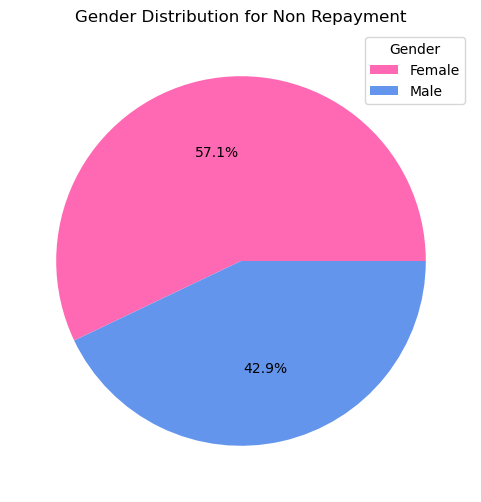

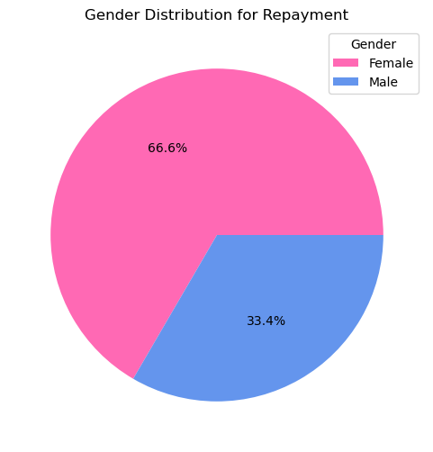

```python
target_1_df = app_train_data[app_train_data['TARGET'] == 1]
target_0_df = app_train_data[app_train_data['TARGET'] == 0]

colors = ['#FF69B4', '#6495ED']
gender_counts_target_1 = target_1_df['CODE_GENDER'].value_counts()
gender_counts_target_0 = target_0_df['CODE_GENDER'].value_counts()
# Plotting the pie chart for Target=1
plt.figure(figsize=(6, 6))
plt.pie(gender_counts_target_1, autopct='%1.1f%%', colors=colors)
plt.title('Gender Distribution for Non Repayment')
plt.legend(title='Gender', labels=['Female', 'Male'])
plt.show()

# Plotting the pie chart for Target=0
plt.figure(figsize=(6, 6))
plt.pie(gender_counts_target_0, autopct='%1.1f%%', colors=colors)
plt.title('Gender Distribution for Repayment')
plt.legend(title='Gender', labels=['Female', 'Male'])
plt.show()
```

```python
# According to this distribution, why female customers are more inclined to pay back but also are inclined to not pay?
```

## 5.6 Relationship Between Contract Type and Target

```python
app_train_data['NAME_CONTRACT_TYPE'].value_counts()
```

```
Cash loans         278232
Revolving loans     29275
Name: NAME_CONTRACT_TYPE, dtype: int64
```

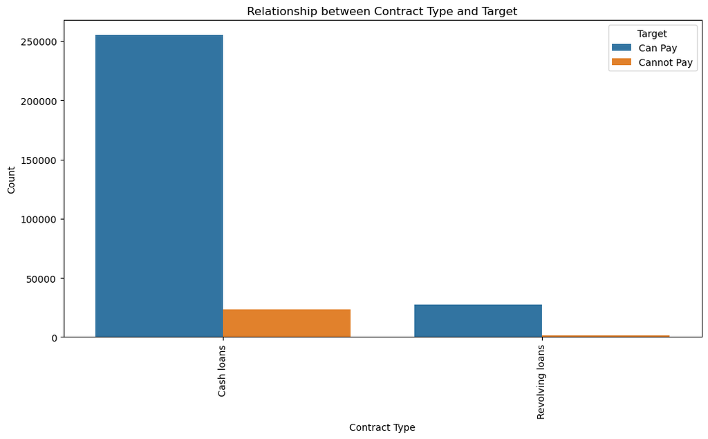

```python
sorted_occupations = app_train_data['NAME_CONTRACT_TYPE'].value_counts().sort_values(ascending=False).index
plt.figure(figsize=(12, 6))
sns.countplot(data=app_train_data, x='NAME_CONTRACT_TYPE', hue='TARGET',order=sorted_occupations)
plt.xticks(rotation=90)
plt.xlabel('Contract Type')
plt.ylabel('Count')
plt.title('Relationship between Contract Type and Target')
plt.legend(title='Target', labels=['Can Pay', 'Cannot Pay'])
plt.show()
```

back to top

# 6. Finding Correlation

```python
correlation_matrix = app_train_data.corr()
target_correlation = correlation_matrix['TARGET']
target_correlation_sorted = target_correlation.sort_values(ascending=False)
target_correlation_sorted.head()
```

```
TARGET                         1.000000
DAYS_BIRTH                     0.078242
REGION_RATING_CLIENT_W_CITY    0.060895
REGION_RATING_CLIENT           0.058901
DAYS_LAST_PHONE_CHANGE         0.055219
Name: TARGET, dtype: float64
```

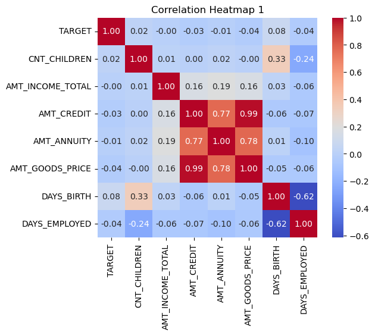

```python
selected_columns = ['TARGET','CNT_CHILDREN','AMT_INCOME_TOTAL','AMT_CREDIT','AMT_ANNUITY','AMT_GOODS_PRICE','DAYS_BIRTH','DAYS_EMPLOYED']
subset_corr_matrix = correlation_matrix.loc[selected_columns, selected_columns]

# Generate a heatmap using seaborn for the subset correlation matrix
sns.heatmap(subset_corr_matrix, cmap='coolwarm', annot=True, fmt=".2f", square=True)

# Set the plot title
plt.title('Correlation Heatmap 1')

# Display the heatmap
plt.show()
```

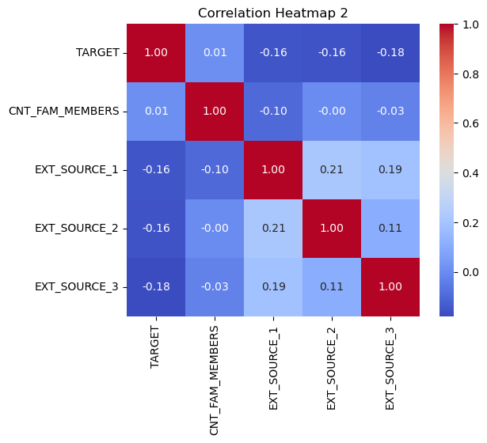

```python
selected_columns = ['TARGET','CNT_FAM_MEMBERS','EXT_SOURCE_1','EXT_SOURCE_2','EXT_SOURCE_3']
subset_corr_matrix = correlation_matrix.loc[selected_columns, selected_columns]

# Generate a heatmap using seaborn for the subset correlation matrix
sns.heatmap(subset_corr_matrix, cmap='coolwarm', annot=True, fmt=".2f", square=True)

# Set the plot title
plt.title('Correlation Heatmap 2')

# Display the heatmap
plt.show()
```

back to top

# 7. Outliers

```python
# Selecting only numerical columns
numerical_columns = app_train_data.select_dtypes(include=[np.number])

z_scores = (numerical_columns - numerical_columns.mean()) / numerical_columns.std()

threshold = 3
outliers = (z_scores > threshold) | (z_scores < -threshold)

outlier_percentages = (outliers.sum() / outliers.shape[0]) * 100
print(outlier_percentages.sort_values(ascending=False))
```

```
FLAG_DOCUMENT_6            8.805653
FLAG_DOCUMENT_8            8.137701
TARGET                     8.072987
REG_CITY_NOT_LIVE_CITY     7.817383
FLAG_EMAIL                 5.672066
                             ...
EXT_SOURCE_2               0.000000
DAYS_BIRTH                 0.000000
REG_CITY_NOT_WORK_CITY     0.000000
LIVE_CITY_NOT_WORK_CITY    0.000000
SK_ID_CURR                 0.000000
Length: 106, dtype: float64
```

## 7.1 Fixing Days Employed Values

```python
app_train_data['DAYS_EMPLOYED'].describe()
#We can see that the minimum values of days employed is negative which should not be the case. We have to fix this.
#Also, there is a repeating value
```

```
count    307507.000000
mean      63815.929208
std      141276.472519
min      -17912.000000
25%       -2760.000000
50%       -1213.000000
75%        -289.000000
max      365243.000000
Name: DAYS_EMPLOYED, dtype: float64
```

```python
app_train_data['DAYS_EMPLOYED']=app_train_data['DAYS_EMPLOYED'].abs()

mean_value = app_train_data.loc[app_train_data['DAYS_EMPLOYED'] != 365243, 'DAYS_EMPLOYED'].mean()
app_train_data['DAYS_EMPLOYED'].replace(365243, mean_value, inplace=True)
```

```python
app_train_data['DAYS_EMPLOYED'].describe()
```

```
count    307507.000000
mean       2384.142254
std        2117.349523
min           0.000000
25%         933.000000
50%        2219.000000
75%        2760.000000
max       17912.000000
Name: DAYS_EMPLOYED, dtype: float64
```

## 7.2 Fixing Children Count

```python
app_train_data['CNT_CHILDREN'].value_counts()
#More than 7 children looks like an outlier, lets fix it!
```

```
0     215369
1      61118
2      26748
3       3717
4        429
5         84
6         21
7          7
14         3
8          2
9          2
12         2
10         2
19         2
11         1
Name: CNT_CHILDREN, dtype: int64
```

```python
outlier_threshold = 7

app_train_data['CNT_CHILDREN'] = app_train_data['CNT_CHILDREN'].where(app_train_data['CNT_CHILDREN'] <= outlier_threshold, outlier_threshold)
```

```python
app_train_data['CNT_CHILDREN'].value_counts()
```

```
0    215369
1     61118
2     26748
3      3717
4       429
5        84
7        21
6        21
Name: CNT_CHILDREN, dtype: int64
```

## 7.3 Fixing Days Birth, Days ID Publish, Days Registration

```python
app_train_data['DAYS_BIRTH']=app_train_data['DAYS_BIRTH'].abs()
app_train_data['DAYS_EMPLOYED']=app_train_data['DAYS_EMPLOYED'].abs()
app_train_data['DAYS_REGISTRATION']=app_train_data['DAYS_REGISTRATION'].abs()
app_train_data['DAYS_LAST_PHONE_CHANGE']=app_train_data['DAYS_LAST_PHONE_CHANGE'].abs()
```

```python
print(app_train_data['DAYS_BIRTH'].head())
print(app_train_data['DAYS_EMPLOYED'].head())
print(app_train_data['DAYS_REGISTRATION'].head())
print(app_train_data['DAYS_LAST_PHONE_CHANGE'].head())
```

```
0     9461
1    16765
2    19046
3    19005
4    19932
Name: DAYS_BIRTH, dtype: int64
0     637.0
1    1188.0
2     225.0
3    3039.0
4    3038.0
Name: DAYS_EMPLOYED, dtype: float64
0    3648.0
1    1186.0
2    4260.0
3    9833.0
4    4311.0
Name: DAYS_REGISTRATION, dtype: float64
0    1134.0
1     828.0
2     815.0
3     617.0
4    1106.0
Name: DAYS_LAST_PHONE_CHANGE, dtype: float64
```

back to top

# 8. Contributions

### 1. Krishna Chaitanya: Business Problem Statement, Missing Data, Outliers, Correlations

### 2. Anukriti: Business Problem Statement, Data Description, Target Variable Distribution, Table of Contents

### 3. Shivi Shrivastav: Business Problem Statement, Table of Contents, Missing Data, Correlation Matrix

### 4. Litzy Carbajal: Business Problem Statement, Missing Data, Outliers, Target Variable Distribution

back to top